# week 7

Chong Zhang

February 26, 2018

# 10.1

## regression tree model with all predictors

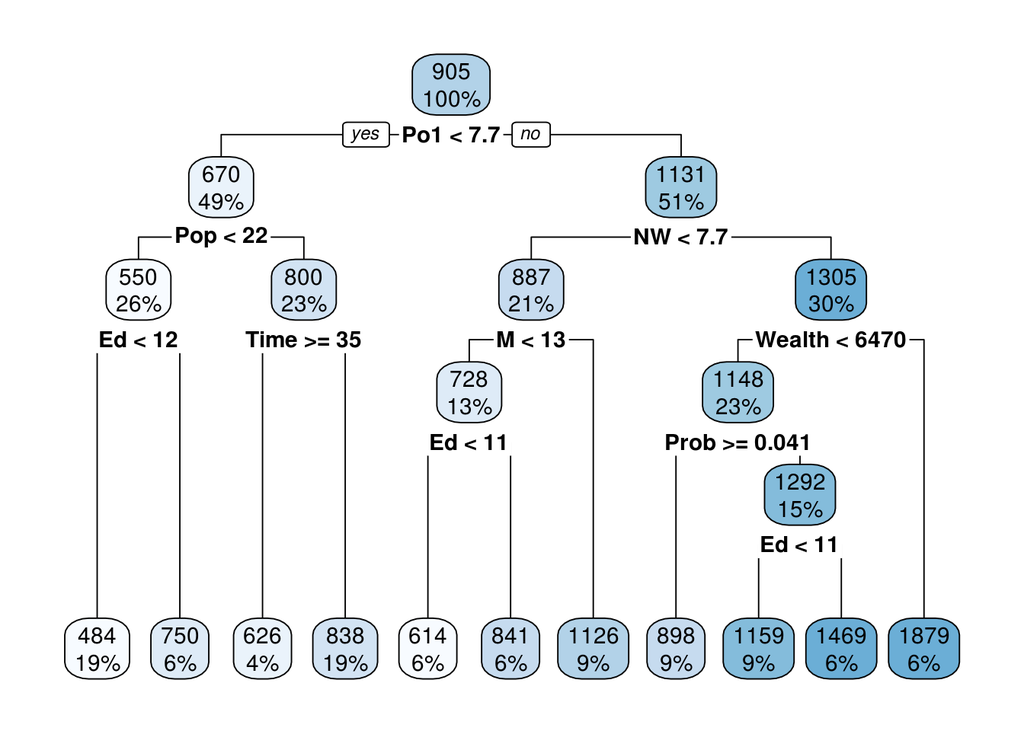

```r
library(rpart.plot)
library(rpart)
library(ggplot2)
library(dplyr)

# load data
crime = read.csv('uscrime.txt', sep = '', header = T, stringsAsFactors = F)
# set the control parameter, each node must have at least 10% of the data
control = rpart.control(minsplit = 0.1*nrow(crime), cp=0.01, xval = 10)
# fit the dependent variable with all predictors
tree_1 = rpart(Crime~., data = crime, control = control)
rpart.plot(tree_1)
```

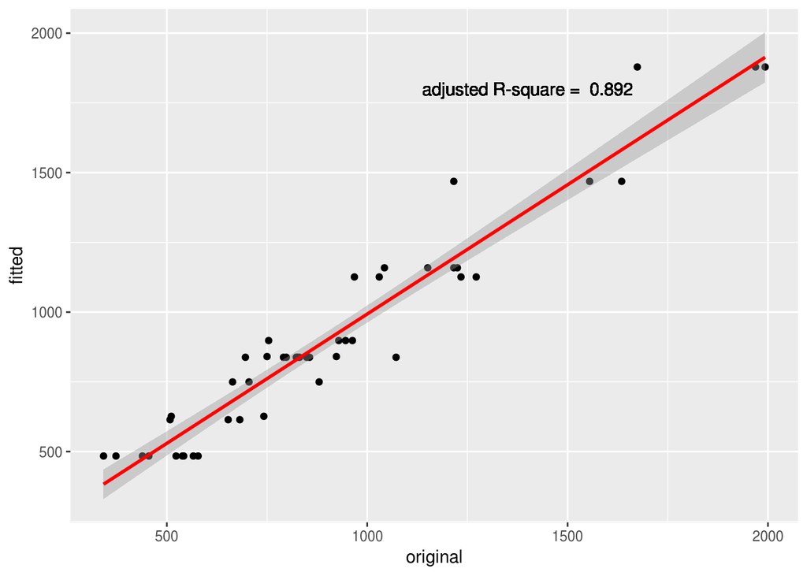

```r
# calculate the adjusted R squared
SST = sum((crime$Crime-mean(crime$Crime))^2)
SSR = sum((predict(tree_1)-crime$Crime)^2)
R_squred = 1-(SSR/SST)
adj.R_squared = 1-((1-R_squred)*(nrow(crime)-1)/(nrow(crime)-15-1))

# visulize the fitted value with original value
datas = data.frame(original = crime$Crime, fitted = predict(tree_1))
p = ggplot(data = datas,aes(x=original, y= fitted))+
  geom_point()+
  geom_smooth(method = 'lm', color = 'Red')+
  geom_text(aes(1400, 1800), label=paste('adjusted R-square = ',round(adj.R_squared,3)))
p
```

## use partial predictors to build the regression tree model

In homework 5, I used M+Ed+Po1+Pop+U1+U2+Ineq+Prob to build the final model, which gave me the highest adj.R_squared. Thus I decied to use those precitors with the same control parameter to build my regression tree model.

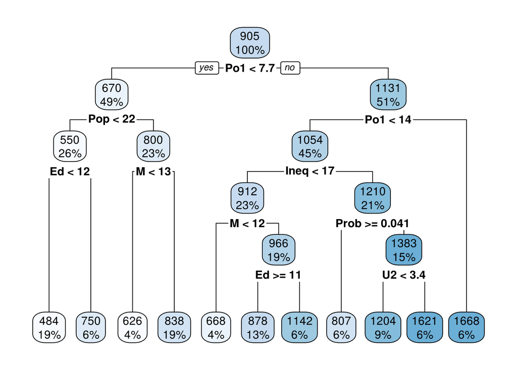

```r
# using the same control parameters
tree_2 = rpart(Crime~M+Ed+Po1+Pop+U1+U2+Ineq+Prob, data = crime, control = control)
rpart.plot(tree_2)
```

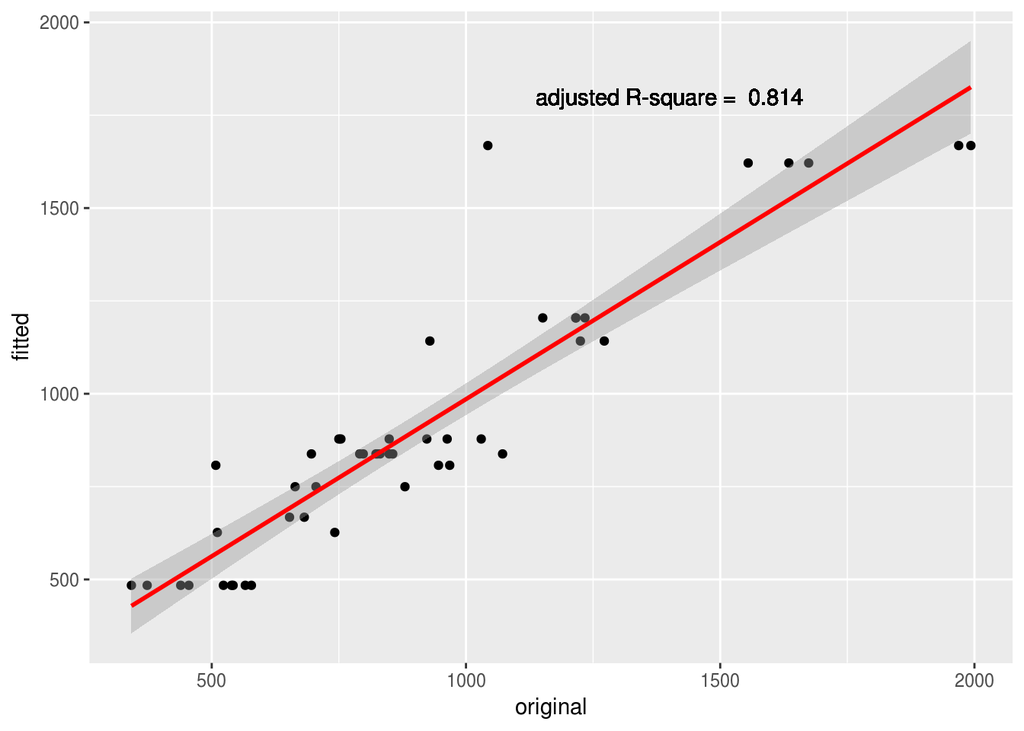

```r
# calculate the adjusted R squared
SST = sum((crime$Crime-mean(crime$Crime))^2)
SSR = sum((predict(tree_2)-crime$Crime)^2)
R_squred = 1-(SSR/SST)
adj.R_squared = 1-((1-R_squred)*(nrow(crime)-1)/(nrow(crime)-8-1))

# visulize the fitted value with original value
datas = data.frame(original = crime$Crime, fitted = predict(tree_2))
p = ggplot(data = datas,aes(x=original, y= fitted))+
  geom_point()+
  geom_smooth(method = 'lm', color = 'Red')+
  geom_text(aes(1400, 1800), label=paste('adjusted R-square = ',round(adj.R_squared,3)))
p
```

Based on what I have from the two regression tree models. It looks like the model with **all the variables** is better than the model untilizing **M+Ed+Po1+Pop+U1+U2+Ineq+Prob**. Also, the adj.R_squared is significantly higher than that of the linear regression model with the same set of predictors. This might be because of the parameters I set. Thus this could lead to over-fitting.

## Random forest model

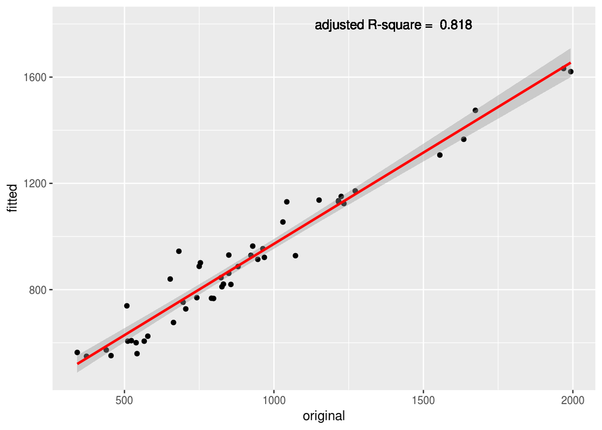

```r
set.seed(666)
library(caret)
library(randomForest)
# set up the training parameter for 10-fold Cross-validation
tc = trainControl(method = 'cv', number = 10)
# build the randomforest model based on all the predictors
rf_1 = train(Crime~., data=crime, trControl = tc)

# calculate the adjusted R squared
SST = sum((crime$Crime-mean(crime$Crime))^2)
SSR = sum((predict(rf_1)-crime$Crime)^2)
R_squred = 1-(SSR/SST)
adj.R_squared = 1-((1-R_squred)*(nrow(crime)-1)/(nrow(crime)-15-1))

# visulize the fitted value with original value
datas = data.frame(original = crime$Crime, fitted = predict(rf_1))
p = ggplot(data = datas,aes(x=original, y= fitted))+
  geom_point()+
  geom_smooth(method = 'lm', color = 'Red')+
  geom_text(aes(1400, 1800), label=paste('adjusted R-square = ',round(adj.R_squared,3)))
p
```

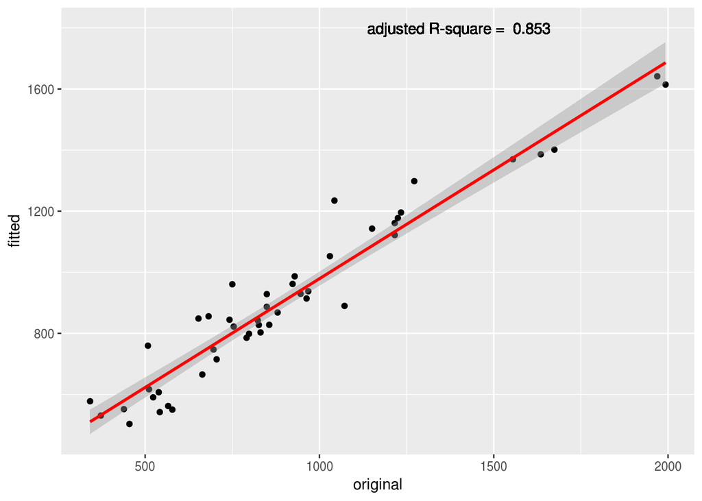

```r
# build the randomforest model based on partial predictors
rf_2 = train(Crime~M+Ed+Po1+Pop+U1+U2+Ineq+Prob, data=crime, trControl = tc)

# calculate the adjusted R squared
SST = sum((crime$Crime-mean(crime$Crime))^2)
SSR = sum((predict(rf_2)-crime$Crime)^2)
R_squred = 1-(SSR/SST)
adj.R_squared = 1-((1-R_squred)*(nrow(crime)-1)/(nrow(crime)-8-1))

# visulize the fitted value with original value
datas = data.frame(original = crime$Crime, fitted = predict(rf_2))
p = ggplot(data = datas,aes(x=original, y= fitted))+
  geom_point()+
  geom_smooth(method = 'lm', color = 'Red')+
  geom_text(aes(1400, 1800), label=paste('adjusted R-square = ',round(adj.R_squared,3)))
p
```

Based on those two random forest models, I conclude that the model using partial variables are better based on **adj.R-squared**. Since random forest is like a blackbox method for prediction. It is really hard to interpret the model.

# 10.2

I worked in a lab that conducting research on Plant Pathology. I can use logistic regression to predict the probability that whether a plant in the filed will develop fungal disease. Because fungal diseases can be affected by many factors such as daily average temperature, highest temperature, lowest temperature, humidity, daytime length and whether simialr disease outbroke last year. Thus I can use all of those as predictors to model the probability of whether a plant will develop such fungal disease.

# 10.3

## 10.3.1

### logistic regression on German Credit data

```r
library(pROC)
library(pscl)
# read data
germancredit = read.csv('gernmancredit.txt', sep='', stringsAsFactors = T, header = F)
# change the last columm which is the dependent variable to be 1 and 0.
germancredit = mutate(germancredit, V21=as.factor(if_else(V21==1,1,0)))

# fit the dependent variable V21 with all other variables
lr_1 = glm(V21~., data = germancredit, family=binomial(link = 'logit'))
summary(lr_1)
```

```
##
## Call:
## glm(formula = V21 ~ ., family = binomial(link = "logit"), data = germancredit)
##
## Deviance Residuals:
##     Min       1Q   Median       3Q      Max
## -2.6116  -0.7095   0.3752   0.6994   2.3410
##
## Coefficients:
##               Estimate Std. Error z value Pr(>|z|)
## (Intercept) -4.005e-01  1.084e+00  -0.369 0.711869
## V1A12        3.749e-01  2.179e-01   1.720 0.085400 .
## V1A13        9.657e-01  3.692e-01   2.616 0.008905 **
## V1A14        1.712e+00  2.322e-01   7.373 1.66e-13 ***
## V2          -2.786e-02  9.296e-03  -2.997 0.002724 **
## V3A31       -1.434e-01  5.489e-01  -0.261 0.793921
## V3A32        5.861e-01  4.305e-01   1.362 0.173348
## V3A33        8.532e-01  4.717e-01   1.809 0.070470 .
## V3A34        1.436e+00  4.399e-01   3.264 0.001099 **
## V4A41        1.666e+00  3.743e-01   4.452 8.51e-06 ***
## V4A410       1.489e+00  7.764e-01   1.918 0.055163 .
## V4A42        7.916e-01  2.610e-01   3.033 0.002421 **
## V4A43        8.916e-01  2.471e-01   3.609 0.000308 ***
## V4A44        5.228e-01  7.623e-01   0.686 0.492831
## V4A45        2.164e-01  5.500e-01   0.393 0.694000
## V4A46       -3.628e-02  3.965e-01  -0.092 0.927082
## V4A48        2.059e+00  1.212e+00   1.699 0.089297 .
## V4A49        7.401e-01  3.339e-01   2.216 0.026668 *
## V5          -1.283e-04  4.444e-05  -2.887 0.003894 **
## V6A62        3.577e-01  2.861e-01   1.250 0.211130
## V6A63        3.761e-01  4.011e-01   0.938 0.348476
## V6A64        1.339e+00  5.249e-01   2.551 0.010729 *
## V6A65        9.467e-01  2.625e-01   3.607 0.000310 ***
## V7A72        6.691e-02  4.270e-01   0.157 0.875475
## V7A73        1.828e-01  4.105e-01   0.445 0.656049
## V7A74        8.310e-01  4.455e-01   1.866 0.062110 .
## V7A75        2.766e-01  4.134e-01   0.669 0.503410
## V8          -3.301e-01  8.828e-02  -3.739 0.000185 ***
## V9A92        2.755e-01  3.865e-01   0.713 0.476040
## V9A93        8.161e-01  3.799e-01   2.148 0.031718 *
```

[output cut: 14 more lines]

```
## V17A173     -5.547e-01  6.549e-01  -0.847 0.397015
## V17A174     -4.795e-01  6.623e-01  -0.724 0.469086
## V18         -2.647e-01  2.492e-01  -1.062 0.288249
## V19A192      3.000e-01  2.013e-01   1.491 0.136060
## V20A202      1.392e+00  6.258e-01   2.225 0.026095 *
## ---
## Signif. codes:  0 '***' 0.001 '**' 0.01 '*' 0.05 '.' 0.1 ' ' 1
##
## (Dispersion parameter for binomial family taken to be 1)
##
##     Null deviance: 1221.73  on 999  degrees of freedom
## Residual deviance:  895.82  on 951  degrees of freedom
## AIC: 993.82
##
## Number of Fisher Scoring iterations: 5
```

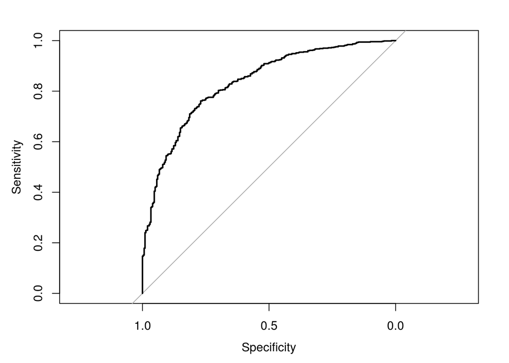

```r
# get the probability for each data point
fitted = predict(lr_1, type = 'response')%>%as.data.frame()
# plot the ROC
datas = data.frame(orignial = germancredit$V21, prob=fitted$.)
roc_1 = roc(orignial~prob, data = datas)
plot(roc_1)
```

```r
# calculate the pseudo r-squared, looking for 'McFadden'
pr_1 = pR2(lr_1)[4]
```

### using AIC to find the optimal model

```r
AIC_model= step(lr_1,trace = F)
print (AIC_model$formula)
```

```
## V21 ~ V1 + V2 + V3 + V4 + V5 + V6 + V8 + V9 + V10 + V13 + V14 +
##     V15 + V19 + V20
```

```r
#thus I can build the model with those variables
lr_2 = glm(V21~V1 + V2 + V3 + V4 + V5 + V6 + V8 + V9 + V10 + V13 + V14 +
    V15 + V19 + V20, data = germancredit, family=binomial(link = 'logit'))
summary(lr_2)
```

```
##
## Call:
## glm(formula = V21 ~ V1 + V2 + V3 + V4 + V5 + V6 + V8 + V9 + V10 +
##     V13 + V14 + V15 + V19 + V20, family = binomial(link = "logit"),
##     data = germancredit)
##
## Deviance Residuals:
##     Min       1Q   Median       3Q      Max
## -2.8176  -0.7449   0.3892   0.6954   2.2588
##
## Coefficients:
##               Estimate Std. Error z value Pr(>|z|)
## (Intercept) -1.750e+00  7.392e-01  -2.367 0.017945 *
## V1A12        3.900e-01  2.121e-01   1.839 0.065928 .
## V1A13        1.024e+00  3.626e-01   2.824 0.004739 **
## V1A14        1.718e+00  2.281e-01   7.531 5.05e-14 ***
## V2          -2.568e-02  8.940e-03  -2.872 0.004074 **
## V3A31        1.188e-01  5.268e-01   0.225 0.821612
## V3A32        8.303e-01  4.106e-01   2.022 0.043169 *
## V3A33        9.097e-01  4.657e-01   1.954 0.050752 .
## V3A34        1.492e+00  4.324e-01   3.450 0.000561 ***
## V4A41        1.607e+00  3.657e-01   4.395 1.11e-05 ***
## V4A410       1.435e+00  7.613e-01   1.885 0.059461 .
## V4A42        7.405e-01  2.534e-01   2.922 0.003475 **
## V4A43        9.195e-01  2.438e-01   3.772 0.000162 ***
## V4A44        5.251e-01  7.369e-01   0.713 0.476116
## V4A45        1.424e-01  5.381e-01   0.265 0.791238
## V4A46       -1.436e-01  3.916e-01  -0.367 0.713918
## V4A48        2.164e+00  1.220e+00   1.774 0.076105 .
## V4A49        7.827e-01  3.272e-01   2.392 0.016752 *
## V5          -1.294e-04  4.221e-05  -3.066 0.002169 **
## V6A62        3.282e-01  2.767e-01   1.186 0.235477
## V6A63        4.304e-01  3.933e-01   1.094 0.273900
## V6A64        1.289e+00  5.072e-01   2.542 0.011008 *
## V6A65        9.628e-01  2.570e-01   3.746 0.000179 ***
## V8          -3.299e-01  8.554e-02  -3.857 0.000115 ***
## V9A92        2.872e-01  3.763e-01   0.763 0.445327
## V9A93        8.228e-01  3.664e-01   2.246 0.024723 *
## V9A94        4.169e-01  4.449e-01   0.937 0.348664
## V10A102     -4.874e-01  3.997e-01  -1.220 0.222648
## V10A103      1.040e+00  4.190e-01   2.483 0.013028 *
## V13          1.309e-02  8.398e-03   1.559 0.118967
## V14A142      7.864e-02  4.033e-01   0.195 0.845394
## V14A143      6.995e-01  2.350e-01   2.976 0.002916 **
## V15A152      4.415e-01  2.220e-01   1.989 0.046707 *
## V15A153      1.497e-01  3.411e-01   0.439 0.660793
## V19A192      2.794e-01  1.842e-01   1.516 0.129394
## V20A202      1.382e+00  6.207e-01   2.227 0.025925 *
## ---
## Signif. codes:  0 '***' 0.001 '**' 0.01 '*' 0.05 '.' 0.1 ' ' 1
##
## (Dispersion parameter for binomial family taken to be 1)
##
##     Null deviance: 1221.7  on 999  degrees of freedom
## Residual deviance:  910.5  on 964  degrees of freedom
## AIC: 982.5
##
## Number of Fisher Scoring iterations: 5
```

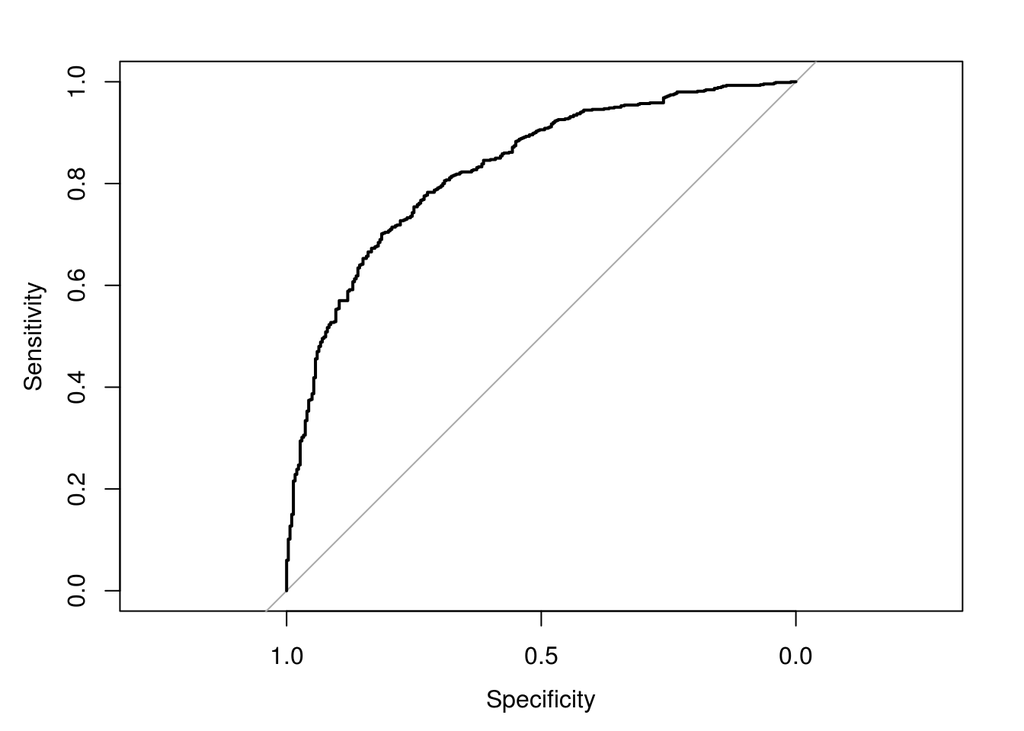

```r
# get the probability for each data point
fitted = predict(lr_2, type = 'response')%>%as.data.frame()

# plot the ROC
datas = data.frame(orignial = germancredit$V21, prob=fitted$.)
roc_2 = roc(orignial~prob, data = datas)
plot(roc_2)
```

```r
# calculate the pseudo r-squared, looking for 'McFadden'
pr_2 = pR2(lr_2)[4]
```

Here we can see that the ROC of both models are quite similar. After comparing the **pseudo r-squared** of both models, **`0.266762` vs `0.2547461`**, I decided to go with the first model that unitlizes all the variables.

All the coefficients are shown below.

```r
print(lr_1$coefficients)
```

```
##   (Intercept)         V1A12         V1A13         V1A14            V2
## -0.4005027032  0.3748533845  0.9656768269  1.7118879549 -0.0278633245
##         V3A31         V3A32         V3A33         V3A34         V4A41
## -0.1433777014  0.5861135632  0.8531614098  1.4357715801  1.6664669545
##        V4A410         V4A42         V4A43         V4A44         V4A45
##  1.4887859369  0.7916103762  0.8915834370  0.5227827424  0.2163959040
##         V4A46         V4A48         V4A49            V5         V6A62
## -0.0362838335  2.0594327737  0.7400868495 -0.0001282747  0.3577405779
##         V6A63         V6A64         V6A65         V7A72         V7A73
##  0.3760728784  1.3391988399  0.9466891929  0.0669104342  0.1828309822
##         V7A74         V7A75            V8         V9A92         V9A93
##  0.8310018182  0.2766245208 -0.3300898152  0.2754548085  0.8160779448
##         V9A94       V10A102       V10A103           V11       V12A122
##  0.3670718835 -0.4360476126  0.9786160157 -0.0047760501 -0.2814382403
##       V12A123       V12A124           V13       V14A142       V14A143
## -0.1945346780 -0.7304477374  0.0145354910  0.1232005664  0.6463286585
##       V15A152       V15A153           V16       V17A172       V17A173
##  0.4436209848  0.6838601772 -0.2720759275 -0.5361303832 -0.5547174978
##       V17A174           V18       V19A192       V20A202
## -0.4794752439 -0.2646713870  0.3000079729  1.3922159416
```

## 10.3.2

Since in the data, they estimate that incorrectly identifying a bad customer as good, is 5 times worse than incorrectly classifying a good customer as bad. Setting the threshold probability to max minimize the loss

```r
# initilize an empty vector for stroage
loss_all = c()
fitted = predict(lr_1,type = 'response')%>%as.data.frame()
# using a for loop to go through all the probabilities
for (i in seq(0.05, 0.99, by = 0.01)){
  # get the predicted outcome based on the probability, 1 for good, 0 for bad
  fitted = mutate(fitted, outcome=if_else(.>i,1,0))
  # store the original and predicted outcome in a data.frame
  df = data.frame(original = germancredit$V21, fitted = fitted$outcome)
  # get the confusionMatrix
  cm = confusionMatrix(df$original,df$fitted)
  table = cm$table
  # calculate the loss
  loss = table[1,2]*5+table[2,1]*1
  loss_all = c(loss_all,loss)
}
loss_all=data.frame(p=seq(0.05, 0.99, by = 0.01), loss_all=loss_all)

# get the probability for the lowest loss
row = which.min(loss_all[,2])
print (loss_all[row,])
```

```
##       p loss_all
## 83 0.87      457
```

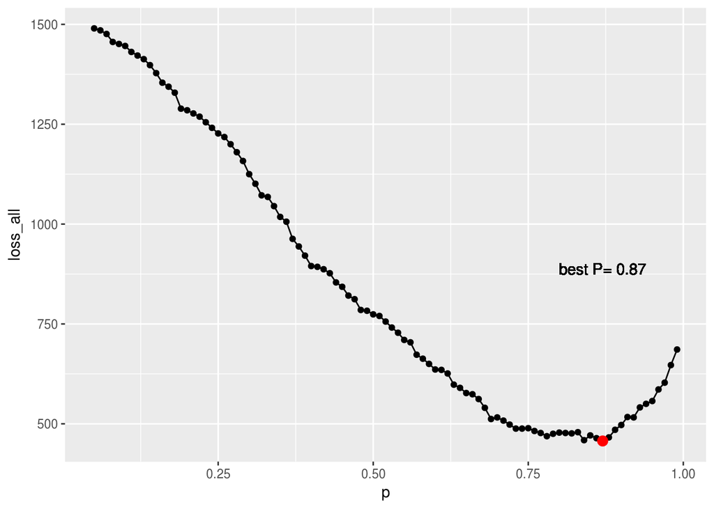

```r
# plot
p = ggplot(loss_all, aes(x=p, y=loss_all))+geom_point()+geom_line()
p = p + geom_point(data = loss_all[row,],aes(x=p, y= loss_all), color = 'red',size=3)
p = p + geom_text(aes(0.87, 888), label=paste('best P=',round(loss_all[row,1],2)))
p
```

Thus the cost will be minimized when the probability is set to **0.87**.